# P8106_midterm_project_v1

Congyu Yang, Yujing Fu, Zhengkun Ou

2025-03-27

````
``` r
library(pacman)
p_load(tidyverse, caret, tidymodels, corrplot, ggplot2, plotmo, ggrepel, patchwork, earth, pdp, mgcv, knitr)
````

```
##
##  C:\Users\Persica\AppData\Local\Temp\RtmpW2bHWm\downloaded_packages
```

## 1. Data Processing

```r
load("dat1.RData")
load("dat2.RData")
```

```r
skimr::skim(dat1)
```

Data summary

| Name | dat1 |
| --- | --- |
| Number of rows | 5000 |
| Number of columns | 14 |
| _______________________ |  |
| Column type frequency: |  |
| factor | 2 |
| numeric | 12 |
| ________________________ |  |
| Group variables | None |

**Variable type: factor**

| skim_variable | n_missing | complete_rate | ordered | n_unique | top_counts |
| --- | --- | --- | --- | --- | --- |
| race | 0 | 1 | FALSE | 4 | 1: 3221, 3: 1036, 4: 465, 2: 278 |
| smoking | 0 | 1 | FALSE | 3 | 0: 3010, 1: 1504, 2: 486 |

**Variable type: numeric**

| skim_variable | n_missing | complete_rate | mean | sd | p0 | p25 | p50 | p75 | p100 | hist |
| --- | --- | --- | --- | --- | --- | --- | --- | --- | --- | --- |
| id | 0 | 1 | 2500.50 | 1443.52 | 1.00 | 1250.75 | 2500.50 | 3750.25 | 5000.00 | ▇▇▇▇▇ |
| age | 0 | 1 | 59.97 | 4.50 | 44.00 | 57.00 | 60.00 | 63.00 | 75.00 | ▁▃▇▅▁ |
| gender | 0 | 1 | 0.49 | 0.50 | 0.00 | 0.00 | 0.00 | 1.00 | 1.00 | ▇▁▁▁▇ |
| height | 0 | 1 | 170.13 | 5.94 | 150.20 | 166.10 | 170.10 | 174.22 | 192.90 | ▁▅▇▂▁ |
| weight | 0 | 1 | 80.11 | 7.06 | 56.70 | 75.40 | 80.10 | 84.90 | 106.00 | ▁▅▇▃▁ |
| bmi | 0 | 1 | 27.74 | 2.76 | 18.20 | 25.80 | 27.60 | 29.50 | 38.80 | ▁▅▇▂▁ |
| diabetes | 0 | 1 | 0.15 | 0.36 | 0.00 | 0.00 | 0.00 | 0.00 | 1.00 | ▇▁▁▁▂ |
| hypertension | 0 | 1 | 0.46 | 0.50 | 0.00 | 0.00 | 0.00 | 1.00 | 1.00 | ▇▁▁▁▇ |
| SBP | 0 | 1 | 129.90 | 8.00 | 101.00 | 124.00 | 130.00 | 135.00 | 155.00 | ▁▂▇▅▁ |
| LDL | 0 | 1 | 109.91 | 20.15 | 43.00 | 96.00 | 110.00 | 124.00 | 185.00 | ▁▅▇▂▁ |
| time | 0 | 1 | 108.86 | 43.42 | 30.00 | 76.00 | 106.00 | 138.00 | 270.00 | ▆▇▅▂▁ |
| log_antibody | 0 | 1 | 10.06 | 0.60 | 7.77 | 9.68 | 10.09 | 10.48 | 11.96 | ▁▂▇▆▁ |

```r
skimr::skim(dat2)
```

Data summary

| Name | dat2 |
| --- | --- |
| Number of rows | 1000 |
| Number of columns | 14 |
| _______________________ |  |
| Column type frequency: |  |
| factor | 2 |
| numeric | 12 |
| ________________________ |  |
| Group variables | None |

**Variable type: factor**

| skim_variable | n_missing | complete_rate | ordered | n_unique | top_counts |
| --- | --- | --- | --- | --- | --- |
| race | 0 | 1 | FALSE | 4 | 1: 663, 3: 199, 4: 83, 2: 55 |
| smoking | 0 | 1 | FALSE | 3 | 0: 601, 1: 296, 2: 103 |

**Variable type: numeric**

| skim_variable | n_missing | complete_rate | mean | sd | p0 | p25 | p50 | p75 | p100 | hist |
| --- | --- | --- | --- | --- | --- | --- | --- | --- | --- | --- |
| id | 0 | 1 | 5500.50 | 288.82 | 5001.00 | 5250.75 | 5500.50 | 5750.25 | 6000.00 | ▇▇▇▇▇ |
| age | 0 | 1 | 60.02 | 4.45 | 46.00 | 57.00 | 60.00 | 63.00 | 75.00 | ▁▃▇▃▁ |
| gender | 0 | 1 | 0.49 | 0.50 | 0.00 | 0.00 | 0.00 | 1.00 | 1.00 | ▇▁▁▁▇ |
| height | 0 | 1 | 170.22 | 6.02 | 149.40 | 166.10 | 170.20 | 174.20 | 190.60 | ▁▃▇▃▁ |
| weight | 0 | 1 | 80.13 | 7.05 | 58.80 | 75.30 | 80.20 | 84.40 | 101.60 | ▁▃▇▃▁ |
| bmi | 0 | 1 | 27.72 | 2.82 | 19.80 | 25.80 | 27.60 | 29.60 | 35.80 | ▁▅▇▃▁ |
| diabetes | 0 | 1 | 0.16 | 0.36 | 0.00 | 0.00 | 0.00 | 0.00 | 1.00 | ▇▁▁▁▂ |
| hypertension | 0 | 1 | 0.46 | 0.50 | 0.00 | 0.00 | 0.00 | 1.00 | 1.00 | ▇▁▁▁▇ |
| SBP | 0 | 1 | 129.61 | 8.20 | 106.00 | 124.00 | 130.00 | 135.00 | 156.00 | ▁▅▇▃▁ |
| LDL | 0 | 1 | 110.25 | 20.32 | 46.00 | 96.00 | 112.00 | 124.00 | 174.00 | ▁▅▇▅▁ |
| time | 0 | 1 | 173.77 | 46.78 | 61.00 | 140.00 | 171.00 | 205.00 | 330.00 | ▂▇▇▃▁ |
| log_antibody | 0 | 1 | 9.90 | 0.59 | 8.05 | 9.50 | 9.93 | 10.31 | 11.85 | ▁▅▇▃▁ |

There is no missing value in this dataset.

```r
colnames(dat1)
```

```
##  [1] "id"           "age"          "gender"       "race"         "smoking"
##  [6] "height"       "weight"       "bmi"          "diabetes"     "hypertension"
## [11] "SBP"          "LDL"          "time"         "log_antibody"
```

```r
# Clean variable names
dat1 = dat1 |> janitor::clean_names()
dat2 = dat2 |> janitor::clean_names()
```

We can see there is no NA values in the dataset.

```r
# Convert variables to factors
dat1$gender <- factor(dat1$gender, levels = c(0, 1), labels = c("Female", "Male"))
dat1$race <- factor(dat1$race, levels = c(1, 2, 3, 4), labels = c("White", "Asian", "Black", "Hispanic"))
dat1$smoking <- factor(dat1$smoking, levels = c(0, 1, 2), labels = c("Never", "Former", "Current"))
dat1$diabetes <- factor(dat1$diabetes, levels = c(0, 1), labels = c("No", "Yes"))
dat1$hypertension <- factor(dat1$hypertension, levels = c(0, 1), labels = c("No", "Yes"))

dat2$gender <- factor(dat2$gender, levels = c(0, 1), labels = c("Female", "Male"))
dat2$race <- factor(dat2$race, levels = c(1, 2, 3, 4), labels = c("White", "Asian", "Black", "Hispanic"))
dat2$smoking <- factor(dat2$smoking, levels = c(0, 1, 2), labels = c("Never", "Former", "Current"))
dat2$diabetes <- factor(dat2$diabetes, levels = c(0, 1), labels = c("No", "Yes"))
dat2$hypertension <- factor(dat2$hypertension, levels = c(0, 1), labels = c("No", "Yes"))
```

```r
# Summary statistics
summary_stats <- summary(dat1)
print(summary_stats)
```

```
##        id            age           gender           race         smoking
##  Min.   :   1   Min.   :44.00   Female:2573   White   :3221   Never  :3010
##  1st Qu.:1251   1st Qu.:57.00   Male  :2427   Asian   : 278   Former :1504
##  Median :2500   Median :60.00                 Black   :1036   Current: 486
##  Mean   :2500   Mean   :59.97                 Hispanic: 465
##  3rd Qu.:3750   3rd Qu.:63.00
##  Max.   :5000   Max.   :75.00
##      height          weight            bmi        diabetes   hypertension
##  Min.   :150.2   Min.   : 56.70   Min.   :18.20   No :4228   No :2702
##  1st Qu.:166.1   1st Qu.: 75.40   1st Qu.:25.80   Yes: 772   Yes:2298
##  Median :170.1   Median : 80.10   Median :27.60
##  Mean   :170.1   Mean   : 80.11   Mean   :27.74
##  3rd Qu.:174.2   3rd Qu.: 84.90   3rd Qu.:29.50
##  Max.   :192.9   Max.   :106.00   Max.   :38.80
##       sbp             ldl             time        log_antibody
##  Min.   :101.0   Min.   : 43.0   Min.   : 30.0   Min.   : 7.765
##  1st Qu.:124.0   1st Qu.: 96.0   1st Qu.: 76.0   1st Qu.: 9.682
##  Median :130.0   Median :110.0   Median :106.0   Median :10.089
##  Mean   :129.9   Mean   :109.9   Mean   :108.9   Mean   :10.064
##  3rd Qu.:135.0   3rd Qu.:124.0   3rd Qu.:138.0   3rd Qu.:10.478
##  Max.   :155.0   Max.   :185.0   Max.   :270.0   Max.   :11.961
```

```r
# Check for missing values
missing_values <- colSums(is.na(dat1))
print(missing_values)
```

```
##           id          age       gender         race      smoking       height
##            0            0            0            0            0            0
##       weight          bmi     diabetes hypertension          sbp          ldl
##            0            0            0            0            0            0
##         time log_antibody
##            0            0
```

There is no missing value in the dataset.

## 2. Exploratory Data Analysis (EDA)

### 2.1 Distribution of log antibody

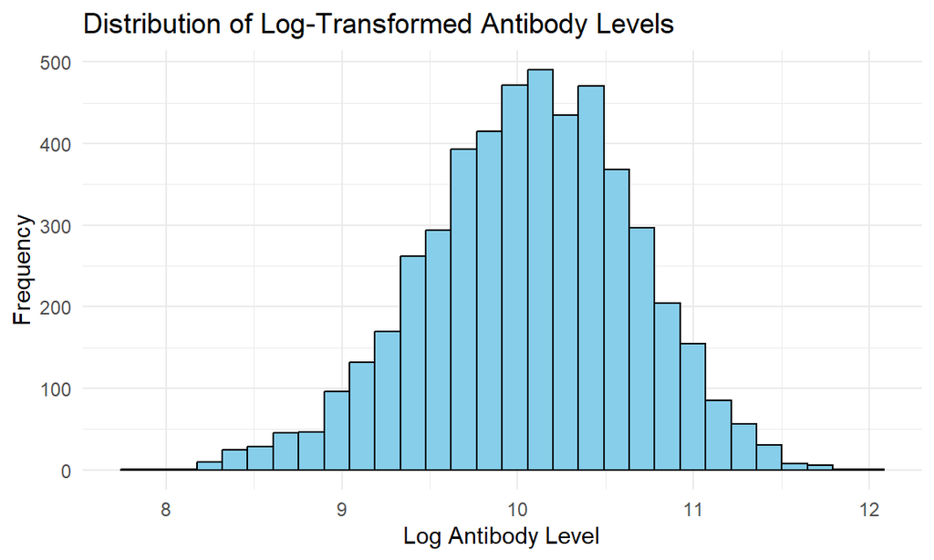

```r
# Distribution of the response variable
p1 <- ggplot(dat1, aes(x = log_antibody)) +
  geom_histogram(fill = "skyblue", color = "black", bins = 30) +
  labs(title = "Distribution of Log-Transformed Antibody Levels",
       x = "Log Antibody Level", y = "Frequency") +
  theme_minimal()
p1
```

### 2.2 Boxplot of log antibody

```r
# Boxplot of log_antibody by gender
p2 <- ggplot(dat1, aes(x = gender, y = log_antibody, fill = gender)) +
  geom_boxplot() +
  labs(title = "Antibody Levels by Gender",
       x = "Gender",
       y = "Log Antibody Level") +
  theme_minimal()

# Boxplot of log_antibody by race
p3 <- ggplot(dat1, aes(x = race, y = log_antibody, fill = race)) +
  geom_boxplot() +
  labs(title = "Antibody Levels by Race/Ethnicity",
       x = "Race/Ethnicity",
       y = "Log Antibody Level") +
  theme_minimal()

# Boxplot of log_antibody by smoking status
p4 <- ggplot(dat1, aes(x = smoking, y = log_antibody, fill = smoking)) +
  geom_boxplot() +
  labs(title = "Antibody Levels by Smoking Status",
       x = "Smoking Status",
       y = "Log Antibody Level") +
  theme_minimal()

# Boxplot of log_antibody by diabetes status
p5 <- ggplot(dat1, aes(x = diabetes, y = log_antibody, fill = diabetes)) +
  geom_boxplot() +
  labs(title = "Antibody Levels by Diabetes Status",
       x = "Diabetes Status",
       y = "Log Antibody Level") +
  theme_minimal()
```

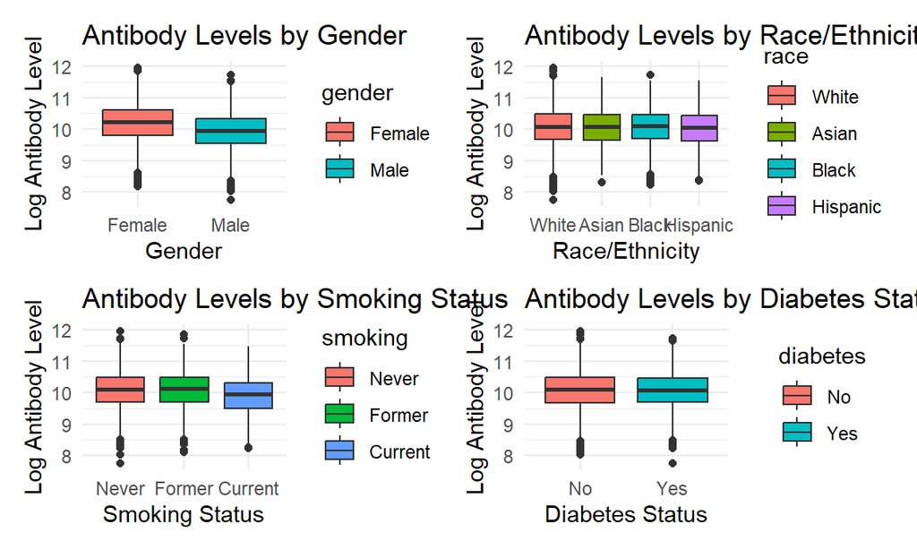

```r
p2+p3+p4+p5
```

### 2.3 Correlation Plot

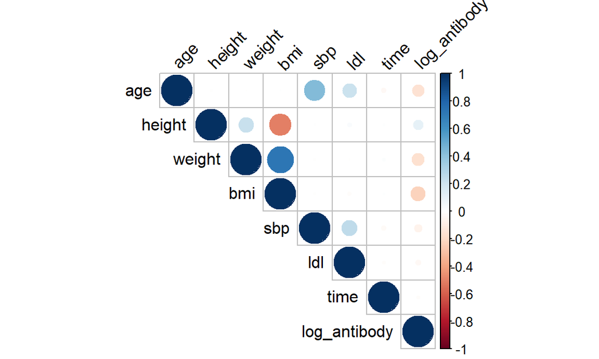

```r
# Scatterplot matrix for continuous variables
continuous_vars <- dat1 %>%
  select(age, height, weight, bmi, sbp, ldl, time, log_antibody)

# Calculate correlation matrix
correlation_matrix <- cor(continuous_vars)
corrplot(correlation_matrix, method = "circle", type = "upper",
         tl.col = "black", tl.srt = 45)
```

### 2.4 Scatterplots

```r
# Create scatterplots for continuous variables vs response
p6 <- ggplot(dat1, aes(x = age, y = log_antibody)) +
  geom_point(alpha = 0.5) +
  geom_smooth(method = "loess", color = "red") +
  labs(title = "Age vs Log Antibody Level",
       x = "Age (years)", y = "Log Antibody Level") +
  theme_minimal()

p7 <- ggplot(dat1, aes(x = bmi, y = log_antibody)) +
  geom_point(alpha = 0.5) +
  geom_smooth(method = "loess", color = "red") +
  labs(title = "BMI vs Log Antibody Level",
       x = "BMI", y = "Log Antibody Level") +
  theme_minimal()

p8 <- ggplot(dat1, aes(x = time, y = log_antibody)) +
  geom_point(alpha = 0.5) +
  geom_smooth(method = "loess", color = "red") +
  labs(title = "Time Since Vaccination vs Log Antibody Level",
       x = "Time (days)", y = "Log Antibody Level") +
  theme_minimal()
```

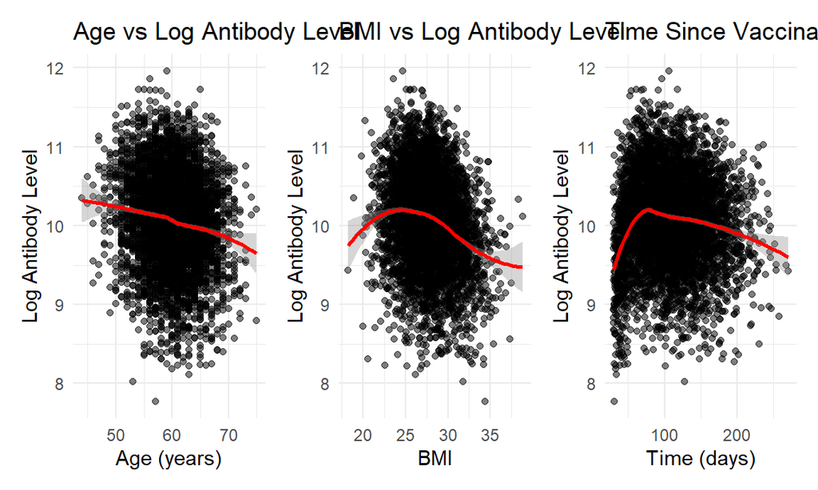

```r
p6+p7+p8
```

There are some potential nonlinear trend between log_antibody and bmi, and between log_antibody and time.

## 3. Model Training with Cross-validation

### 3.1 Linear models

#### 3.1.1 Linear regression

```r
model_formula <- log_antibody ~ . - id

# Set up cross-validation control
ctrl <- trainControl(method = "cv", number = 10)

# 3.1 Linear Regression
set.seed(123)
lm.fit <- train(
  model_formula,
  data = dat1,
  method = "lm",
  trControl = ctrl
)
summary(lm.fit$finalModel)
```

```
##
## Call:
## lm(formula = .outcome ~ ., data = dat)
##
## Residuals:
##      Min       1Q   Median       3Q      Max
## -2.14396 -0.35840  0.02944  0.37802  1.65090
##
## Coefficients:
##                   Estimate Std. Error t value Pr(>|t|)
## (Intercept)     26.6751961  2.3149812  11.523  < 2e-16 ***
## age             -0.0205979  0.0019385 -10.626  < 2e-16 ***
## genderMale      -0.2974929  0.0155977 -19.073  < 2e-16 ***
## raceAsian       -0.0060422  0.0344613  -0.175   0.8608
## raceBlack       -0.0075295  0.0196815  -0.383   0.7021
## raceHispanic    -0.0417571  0.0273309  -1.528   0.1266
## smokingFormer    0.0219907  0.0173992   1.264   0.2063
## smokingCurrent  -0.1934834  0.0269576  -7.177 8.15e-13 ***
## height          -0.0821381  0.0135622  -6.056 1.49e-09 ***
## weight           0.0859034  0.0143481   5.987 2.29e-09 ***
## bmi             -0.2977935  0.0412612  -7.217 6.10e-13 ***
## diabetesYes      0.0112795  0.0215643   0.523   0.6010
## hypertensionYes -0.0179106  0.0260931  -0.686   0.4925
## sbp              0.0015181  0.0017049   0.890   0.3733
## ldl             -0.0001645  0.0004028  -0.409   0.6829
## time            -0.0003011  0.0001795  -1.677   0.0936 .
## ---
## Signif. codes:  0 '***' 0.001 '**' 0.01 '*' 0.05 '.' 0.1 ' ' 1
##
## Residual standard error: 0.5503 on 4984 degrees of freedom
## Multiple R-squared:  0.1513, Adjusted R-squared:  0.1488
## F-statistic: 59.25 on 15 and 4984 DF,  p-value: < 2.2e-16
```

#### 3.1.2 Ridge Regression

```r
set.seed(123)
ridge.fit <- train(
  model_formula,
  data = dat1,
  method = "glmnet",
  tuneGrid = expand.grid(alpha = 0,
                         lambda = exp(seq(6, -6, length = 100))),
  trControl = ctrl
)

coef(ridge.fit$finalModel, s = ridge.fit$bestTune$lambda)
```

```
## 16 x 1 sparse Matrix of class "dgCMatrix"
##                            s1
## (Intercept)     12.7384560516
## age             -0.0197679168
## genderMale      -0.2880871615
## raceAsian       -0.0038318346
## raceBlack       -0.0066654722
## raceHispanic    -0.0417690245
## smokingFormer    0.0242172365
## smokingCurrent  -0.1847225211
## height          -0.0001949552
## weight          -0.0009185524
## bmi             -0.0473178893
## diabetesYes      0.0113069924
## hypertensionYes -0.0166641972
## sbp              0.0010847735
## ldl             -0.0001614795
## time            -0.0002807285
```

```r
print(ridge.fit$bestTune)
```

```
##    alpha    lambda
## 15     0 0.0135275
```

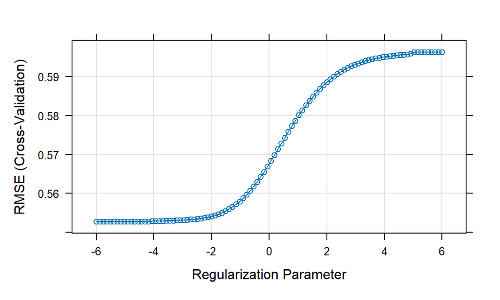

```r
plot(ridge.fit, xTrans = log)
```

#### 3.1.3 Lasso Regression

```r
set.seed(123)
lasso.fit <- train(
  model_formula,
  data = dat1,
  method = "glmnet",
  tuneGrid = expand.grid(alpha = 1,
                         lambda = exp(seq(6, -6, length = 100))),
  trControl = ctrl
)

coef(lasso.fit$finalModel, lasso.fit$bestTune$lambda)
```

```
## 16 x 1 sparse Matrix of class "dgCMatrix"
##                            s1
## (Intercept)      1.272648e+01
## age             -1.915006e-02
## genderMale      -2.859715e-01
## raceAsian        .
## raceBlack        .
## raceHispanic    -2.472809e-02
## smokingFormer    1.593301e-02
## smokingCurrent  -1.770968e-01
## height           .
## weight          -1.029699e-04
## bmi             -4.801089e-02
## diabetesYes      4.273525e-05
## hypertensionYes  .
## sbp              .
## ldl              .
## time            -1.848766e-04
```

```r
print(lasso.fit$bestTune)
```

```
##   alpha      lambda
## 6     1 0.004544037
```

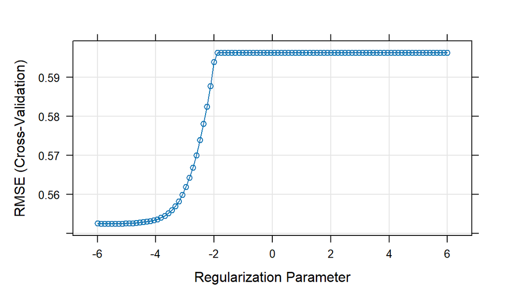

```r
plot(lasso.fit, xTrans = log)
```

#### 3.1.4 Elastic Net Regression

```r
set.seed(123)
enet.fit <- train(
  model_formula,
  data = dat1,
  method = "glmnet",
  tuneGrid = expand.grid(alpha = seq(0, 1, length = 21),
                         lambda = exp(seq(6, -6, length = 100))),
  trControl = ctrl
)
summary(enet.fit)
```

```
##             Length Class      Mode
## a0           100   -none-     numeric
## beta        1500   dgCMatrix  S4
## df           100   -none-     numeric
## dim            2   -none-     numeric
## lambda       100   -none-     numeric
## dev.ratio    100   -none-     numeric
## nulldev        1   -none-     numeric
## npasses        1   -none-     numeric
## jerr           1   -none-     numeric
## offset         1   -none-     logical
## call           5   -none-     call
## nobs           1   -none-     numeric
## lambdaOpt      1   -none-     numeric
## xNames        15   -none-     character
## problemType    1   -none-     character
## tuneValue      2   data.frame list
## obsLevels      1   -none-     logical
## param          0   -none-     list
```

```r
print(enet.fit$bestTune)
```

```
##     alpha      lambda
## 101  0.05 0.002478752
```

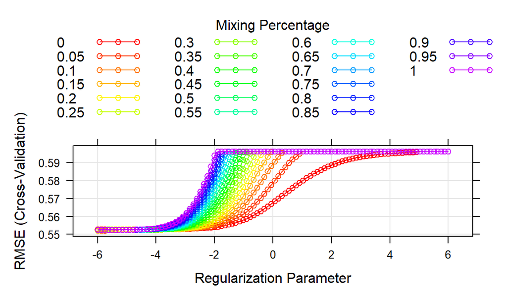

```r
# Plot elastic net results with different colors for each alpha
myCol <- rainbow(25)
myPar <- list(superpose.symbol = list(col = myCol),
              superpose.line = list(col = myCol))
plot(enet.fit, par.settings = myPar, xTrans = log)
```

```r
# Show coefficients of the final Elastic Net model
coef_enet <- coef(enet.fit$finalModel, enet.fit$bestTune$lambda)
print(coef_enet)
```

```
## 16 x 1 sparse Matrix of class "dgCMatrix"
##                            s1
## (Intercept)     16.0225822334
## age             -0.0202906145
## genderMale      -0.2942760076
## raceAsian       -0.0036856007
## raceBlack       -0.0066593257
## raceHispanic    -0.0417893824
## smokingFormer    0.0235504017
## smokingCurrent  -0.1891969582
## height          -0.0193618230
## weight           0.0193847860
## bmi             -0.1063133265
## diabetesYes      0.0111516911
## hypertensionYes -0.0167677112
## sbp              0.0012484795
## ldl             -0.0001495619
## time            -0.0002879691
```

```r
coef_enet <- coef(enet.fit$finalModel, enet.fit$bestTune$lambda)
print(coef_enet)
```

```
## 16 x 1 sparse Matrix of class "dgCMatrix"
##                            s1
## (Intercept)     16.0225822334
## age             -0.0202906145
## genderMale      -0.2942760076
## raceAsian       -0.0036856007
## raceBlack       -0.0066593257
## raceHispanic    -0.0417893824
## smokingFormer    0.0235504017
## smokingCurrent  -0.1891969582
## height          -0.0193618230
## weight           0.0193847860
## bmi             -0.1063133265
## diabetesYes      0.0111516911
## hypertensionYes -0.0167677112
## sbp              0.0012484795
## ldl             -0.0001495619
## time            -0.0002879691
```

#### 3.1.5 Model Comparison (resampling)

```r
resamp <- resamples(list(
  Linear_Regression = lm.fit,
  Ridge = ridge.fit,
  Lasso = lasso.fit,
  Elastic_Net = enet.fit
))
summary(resamp)
```

```
##
## Call:
## summary.resamples(object = resamp)
##
## Models: Linear_Regression, Ridge, Lasso, Elastic_Net
## Number of resamples: 10
##
## MAE
##                        Min.   1st Qu.    Median      Mean   3rd Qu.      Max.
## Linear_Regression 0.4261808 0.4320149 0.4340128 0.4390390 0.4425761 0.4726409
## Ridge             0.4281731 0.4334230 0.4362590 0.4405051 0.4454071 0.4720434
## Lasso             0.4276920 0.4330647 0.4364914 0.4403860 0.4449243 0.4721327
## Elastic_Net       0.4274328 0.4330542 0.4354391 0.4399269 0.4448176 0.4720702
##                   NA's
## Linear_Regression    0
## Ridge                0
## Lasso                0
## Elastic_Net          0
##
## RMSE
##                        Min.   1st Qu.    Median      Mean   3rd Qu.      Max.
## Linear_Regression 0.5325907 0.5394231 0.5513718 0.5507854 0.5564032 0.5835238
## Ridge             0.5363406 0.5426274 0.5535668 0.5527796 0.5570390 0.5837848
## Lasso             0.5362188 0.5422580 0.5529754 0.5525153 0.5572793 0.5834368
## Elastic_Net       0.5354741 0.5414764 0.5531955 0.5519547 0.5560081 0.5834749
##                   NA's
## Linear_Regression    0
## Ridge                0
## Lasso                0
## Elastic_Net          0
##
## Rsquared
##                         Min.   1st Qu.    Median      Mean   3rd Qu.      Max.
## Linear_Regression 0.10033968 0.1319832 0.1534930 0.1479018 0.1622355 0.1906302
## Ridge             0.09354935 0.1329969 0.1421825 0.1418538 0.1502030 0.1878098
## Lasso             0.09475560 0.1342489 0.1433703 0.1428172 0.1503016 0.1912475
## Elastic_Net       0.09585259 0.1339416 0.1458955 0.1443698 0.1542137 0.1902642
##                   NA's
## Linear_Regression    0
## Ridge                0
## Lasso                0
## Elastic_Net          0
```

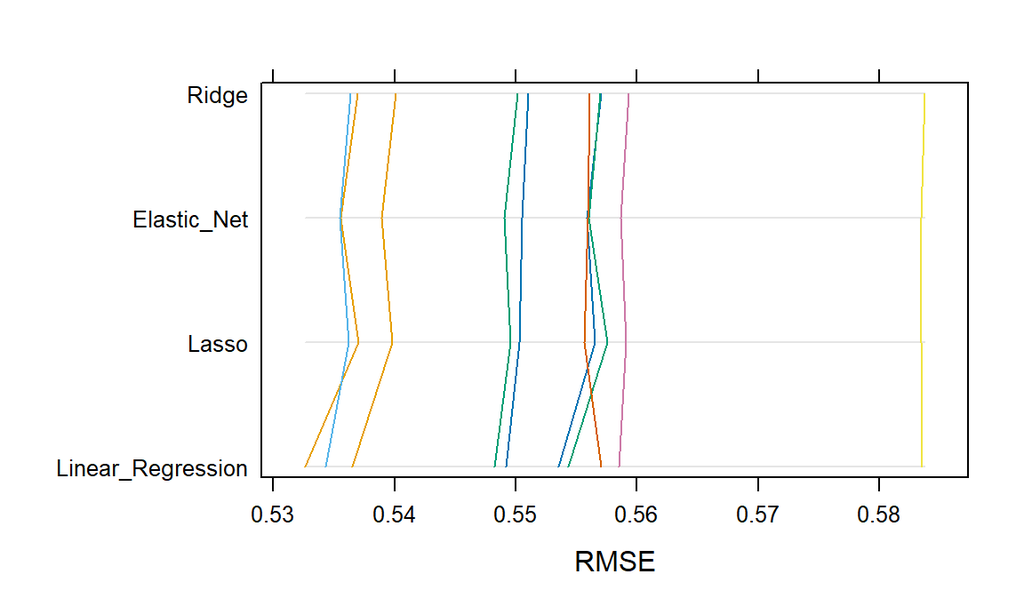

```r
parallelplot(resamp, metric = "RMSE")
```

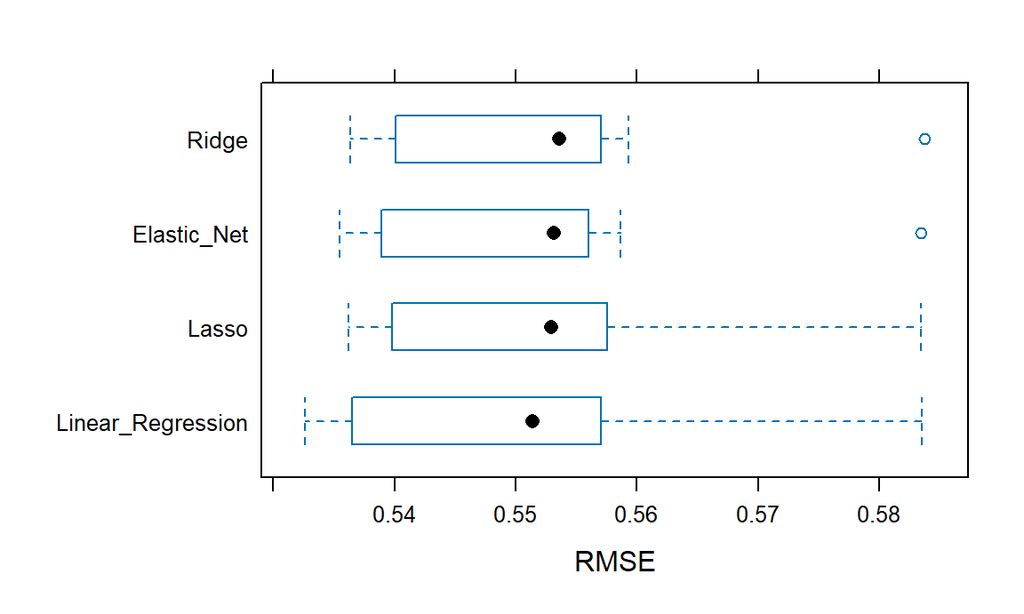

```r
bwplot(resamp, metric = "RMSE")
```

The RMSE from resampling looks similar to each other.

#### 3.1.6 Test Set Performance

```r
# Function to calculate RMSE
rmse <- function(actual, predicted) {
  sqrt(mean((actual - predicted)^2))
}
```

```r
# Make predictions using each model
lm.pred <- predict(lm.fit, newdata = dat2)
ridge.pred <- predict(ridge.fit, newdata = dat2)
lasso.pred <- predict(lasso.fit, newdata = dat2)
enet.pred <- predict(enet.fit, newdata = dat2)
```

```r
# Calculate test MSE for each model
lm.test.error <- mean((lm.pred - dat2[,"log_antibody"])^2)
ridge.test.error <- mean((ridge.pred - dat2[,"log_antibody"])^2)
lasso.test.error <- mean((lasso.pred - dat2[,"log_antibody"])^2)
enet.test.error <- mean((enet.pred - dat2[,"log_antibody"])^2)
```

```r
test_performance <- data.frame(
  Model = c("Linear Regression", "Ridge Regression", "Lasso Regression",
            "Elastic Net Regression"),
  Test_ERROR = c(lm.test.error, ridge.test.error, lasso.test.error,
                enet.test.error)
)
print(test_performance)
```

```
##                    Model Test_ERROR
## 1      Linear Regression  0.3229854
## 2       Ridge Regression  0.3258077
## 3       Lasso Regression  0.3288173
## 4 Elastic Net Regression  0.3247256
```

They are very similar to each other. We probably want to choose the Lasso model as it is the simplest model among those four models.

### 3.2 Non-linear Models

#### 3.2.1 Smoothing Spline

We use scatterplot to explore the relationship between the log antibody level and other continuous variables. Time and bmi tend shows potentially nonlinear trend.

```r
x = model.matrix(log_antibody ~ . - id, data = dat1)[, -1]
y = dat1[,"log_antibody"]
x_test = model.matrix(log_antibody ~ . - id, data = dat2)[, -1]
y_test = dat2[,"log_antibody"]
```

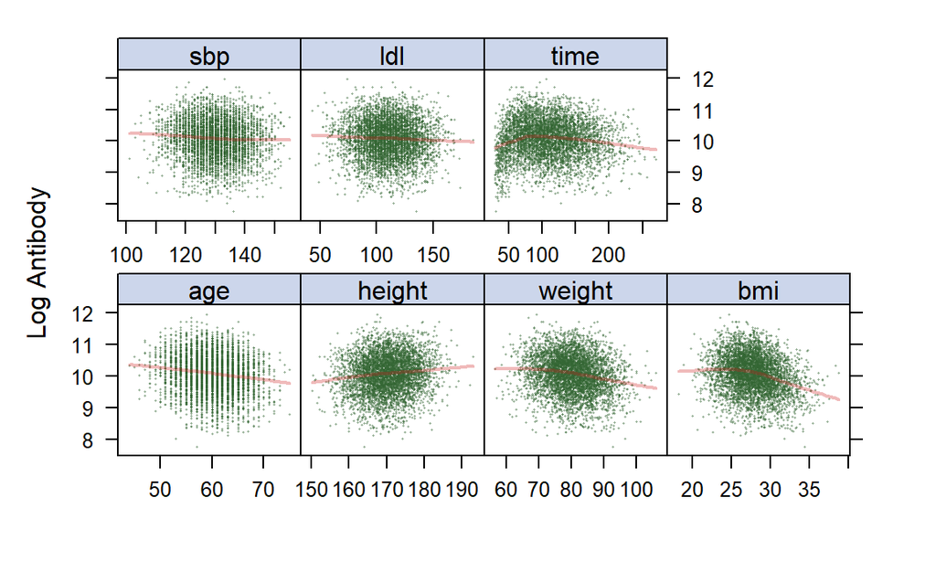

```r
theme1 <- trellis.par.get()
theme1$plot.symbol$col <- rgb(.2, .4, .2, .5)
theme1$plot.symbol$pch <- 16
theme1$plot.symbol$cex <- 0.2
theme1$plot.line$col <- rgb(.8, .1, .1, 0.3)
theme1$plot.line$lwd <- 2
theme1$strip.background$col <- rgb(.0, .2, .6, .2)
# Set the modified parameters as the global style for the trellis graph
trellis.par.set(theme1)
# svi and gleason were not included in the plot (they take discrete values)
featurePlot(x[, c("age", "height", "weight", "bmi", "sbp", "ldl", "time")],
            y,
            plot = "scatter",
            labels = c("", "Log Antibody"),
            type = c("p", "smooth"),
            layout = c(4, 2))
```

```r
# choose the best df
fit.ss = smooth.spline(dat1$bmi, dat1$log_antibody)
fit.ss$df
```

```
## [1] 5.769535
```

```r
print(fit.ss)
```

```
## Call:
## smooth.spline(x = dat1$bmi, y = dat1$log_antibody)
##
## Smoothing Parameter  spar= 0.8460071  lambda= 0.05288648 (13 iterations)
## Equivalent Degrees of Freedom (Df): 5.769535
## Penalized Criterion (RSS): 61.11728
## GCV: 0.3330358
```

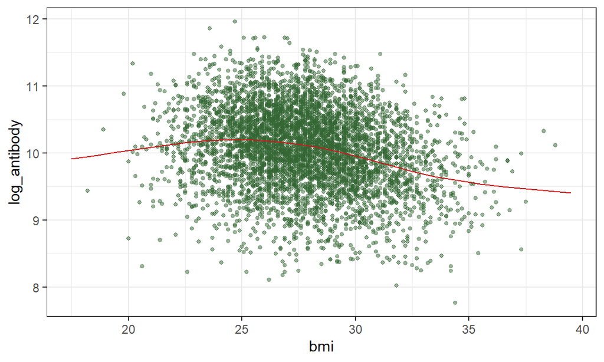

```r
# plot optimal fit
bmi.grid = seq(from = 17.5, to = 40, by = 1)

pred.ss = predict(fit.ss, x = bmi.grid)
pred.ss.df = data.frame(pred = pred.ss$y, bmi = bmi.grid)


p = ggplot(dat1, aes(x = bmi, y = log_antibody)) +
  geom_point(color = rgb(.2, .4, .2, .5), size = 1) + theme_bw()

p +
geom_line(aes(x = bmi, y = pred), data = pred.ss.df,
color = rgb(.8, .1, .1, 1)) + theme_bw()
```

The scatter plot shows a weak non-linear relationship between BMI and log-transformed antibody levels. A smooth spline with an effective degree of freedom of approximately 5.77 was fitted. The trend suggests that antibody levels tend to be higher for individuals with BMI in the range of 25–28 and slightly decrease for higher BMI.

#### 3.2.2 Multivariate Adaptive Regression Splines (MARS)

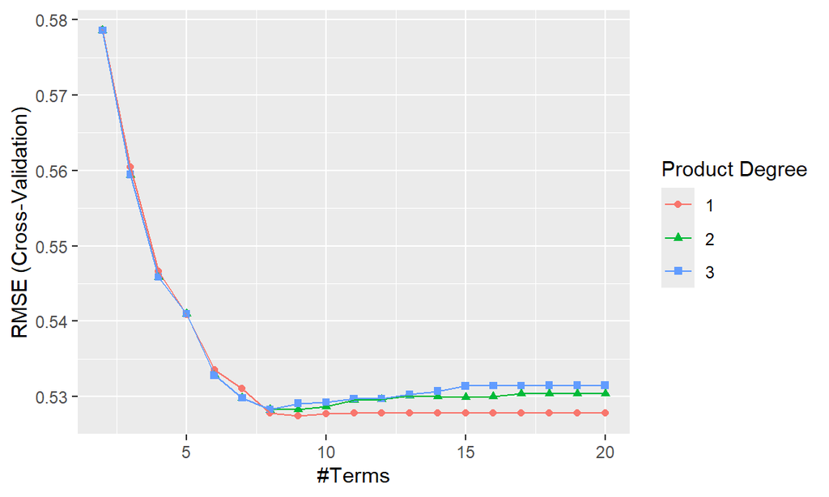

```r
set.seed(123)
ctrl1 = trainControl(method = "cv", number = 10)
mars_grid = expand.grid(degree = 1:3, nprune = 2:20)
mars.fit = train(x, y, method = "earth", tuneGrid = mars_grid,
trControl = ctrl1)
ggplot(mars.fit)
```

```r
mars.fit$bestTune
```

```
##   nprune degree
## 8      9      1
```

```r
coef(mars.fit$finalModel)
```

```
##    (Intercept)    h(27.8-bmi)     h(time-57)     h(57-time)     genderMale
##   10.847446930   -0.061997354   -0.002254182   -0.033529326   -0.296290451
##      h(age-59)      h(59-age) smokingCurrent    h(bmi-23.7)
##   -0.022957648    0.016138468   -0.205126851   -0.084380175
```

```r
summary(mars.fit$finalModel)
```

```
## Call: earth(x=matrix[5000,15], y=c(10.65,9.889,1...), keepxy=TRUE, degree=1,
##             nprune=9)
##
##                coefficients
## (Intercept)      10.8474469
## genderMale       -0.2962905
## smokingCurrent   -0.2051269
## h(59-age)         0.0161385
## h(age-59)        -0.0229576
## h(bmi-23.7)      -0.0843802
## h(27.8-bmi)      -0.0619974
## h(57-time)       -0.0335293
## h(time-57)       -0.0022542
##
## Selected 9 of 10 terms, and 5 of 15 predictors (nprune=9)
## Termination condition: RSq changed by less than 0.001 at 10 terms
## Importance: bmi, genderMale, time, age, smokingCurrent, raceAsian-unused, ...
## Number of terms at each degree of interaction: 1 8 (additive model)
## GCV 0.2787787    RSS 1384.431    GRSq 0.2166152    RSq 0.2216218
```

We fitted a MARS model with 10-fold cross-validation. The optimal model selected 9 basis functions with degree 1 (additive model). Among 15 candidate predictors, 5 variables were retained (bmi, gender, time, age, and smoking). The fitted model explained approximately 22% of the variation in log-transformed antibody levels. The model identified several meaningful breakpoints such as bmi = 23.7 and bmi = 27.8, suggesting non-linear relationships. For example, BMI showed a negative effect on antibody levels when exceeding 23.7, and males had lower antibody levels compared to females.

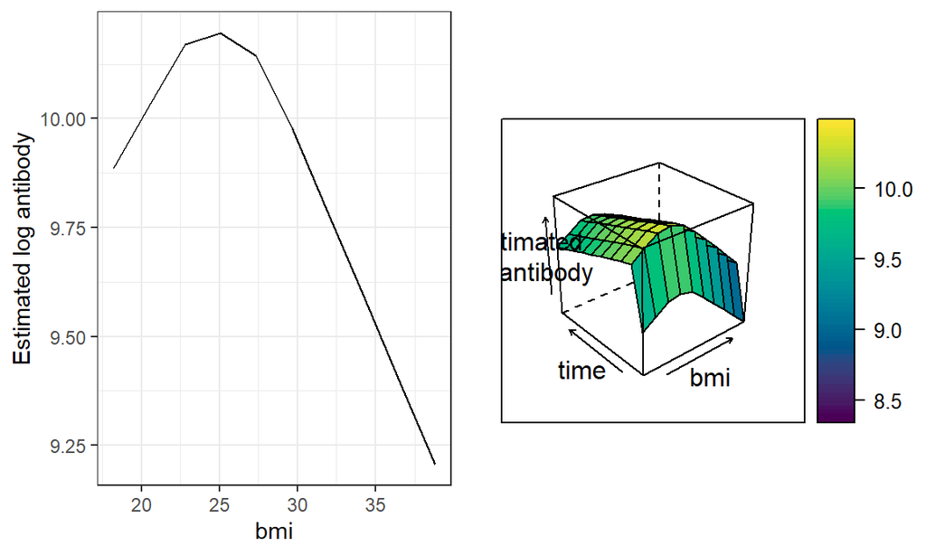

```r
# we choose the relatively important variables to draw partial dependence plot
pdp1 = pdp::partial(mars.fit, pred.var = c("bmi"), grid.resolution = 10) |>
  autoplot() +
  ylab("Estimated log antibody") +
  xlab("bmi") +
  theme_bw()

pdp2 = pdp::partial(mars.fit, pred.var = c("bmi", "time"), grid.resolution = 10) |>
  pdp::plotPartial(levelplot = FALSE,
                   zlab = "Estimated\nlog antibody",
                   drape = TRUE)
gridExtra::grid.arrange(pdp1, pdp2, ncol = 2)
```

#### 3.2.3 Generalized Additive Model (GAM)

```r
set.seed(123)
gam.fit = train(x, y, method = "gam", trControl = ctrl1)

summary(gam.fit)
```

```
##
## Family: gaussian
## Link function: identity
##
## Formula:
## .outcome ~ genderMale + raceAsian + raceBlack + raceHispanic +
##     smokingFormer + smokingCurrent + diabetesYes + hypertensionYes +
##     s(age) + s(sbp) + s(ldl) + s(bmi) + s(time) + s(height) +
##     s(weight)
##
## Parametric coefficients:
##                  Estimate Std. Error t value Pr(>|t|)
## (Intercept)     10.228177   0.015328 667.269  < 2e-16 ***
## genderMale      -0.297837   0.014933 -19.945  < 2e-16 ***
## raceAsian       -0.003296   0.033009  -0.100    0.920
## raceBlack       -0.010509   0.018837  -0.558    0.577
## raceHispanic    -0.037424   0.026176  -1.430    0.153
## smokingFormer    0.022219   0.016660   1.334    0.182
## smokingCurrent  -0.193175   0.025834  -7.478  8.9e-14 ***
## diabetesYes      0.014230   0.020640   0.689    0.491
## hypertensionYes -0.007678   0.015995  -0.480    0.631
## ---
## Signif. codes:  0 '***' 0.001 '**' 0.01 '*' 0.05 '.' 0.1 ' ' 1
##
## Approximate significance of smooth terms:
##                 edf Ref.df      F p-value
## s(age)    9.908e-01      9 13.733  <2e-16 ***
## s(sbp)    6.175e-07      9  0.000   0.765
## s(ldl)    6.648e-07      9  0.000   0.639
## s(bmi)    4.179e+00      9 41.897  <2e-16 ***
## s(time)   7.892e+00      9 44.960  <2e-16 ***
## s(height) 1.234e+00      9  0.278   0.121
## s(weight) 2.262e-06      9  0.000   0.666
## ---
## Signif. codes:  0 '***' 0.001 '**' 0.01 '*' 0.05 '.' 0.1 ' ' 1
##
## R-sq.(adj) =   0.22   Deviance explained = 22.4%
## GCV = 0.27867  Scale est. = 0.27738   n = 5000
```

```r
gam.fit$bestTune
```

```
##   select method
## 2   TRUE GCV.Cp
```

```r
gam.fit$finalModel
```

```
##
## Family: gaussian
## Link function: identity
##
## Formula:
## .outcome ~ genderMale + raceAsian + raceBlack + raceHispanic +
##     smokingFormer + smokingCurrent + diabetesYes + hypertensionYes +
##     s(age) + s(sbp) + s(ldl) + s(bmi) + s(time) + s(height) +
##     s(weight)
##
## Estimated degrees of freedom:
## 0.991 0.000 0.000 4.179 7.892 1.234 0.000
##  total = 23.3
##
## GCV score: 0.2786734
```

#### 3.2.4 Model Comparison (resampling)

```r
resamp_non_linear <- resamples(list(
  MARS = mars.fit,
  GAM = gam.fit
))
summary(resamp_non_linear)
```

```
##
## Call:
## summary.resamples(object = resamp_non_linear)
##
## Models: MARS, GAM
## Number of resamples: 10
##
## MAE
##           Min.   1st Qu.    Median      Mean  3rd Qu.      Max. NA's
## MARS 0.4078837 0.4098168 0.4163554 0.4220725 0.428591 0.4641090    0
## GAM  0.4078470 0.4112544 0.4168810 0.4225034 0.428161 0.4635896    0
##
## RMSE
##           Min.   1st Qu.    Median      Mean   3rd Qu.      Max. NA's
## MARS 0.5048757 0.5121685 0.5240607 0.5274715 0.5361255 0.5724126    0
## GAM  0.5055708 0.5150506 0.5243183 0.5277724 0.5349189 0.5715483    0
##
## Rsquared
##           Min.   1st Qu.    Median      Mean   3rd Qu.      Max. NA's
## MARS 0.1566346 0.1954579 0.2274358 0.2187657 0.2465799 0.2627660    0
## GAM  0.1586929 0.1935757 0.2259290 0.2177415 0.2449893 0.2595686    0
```

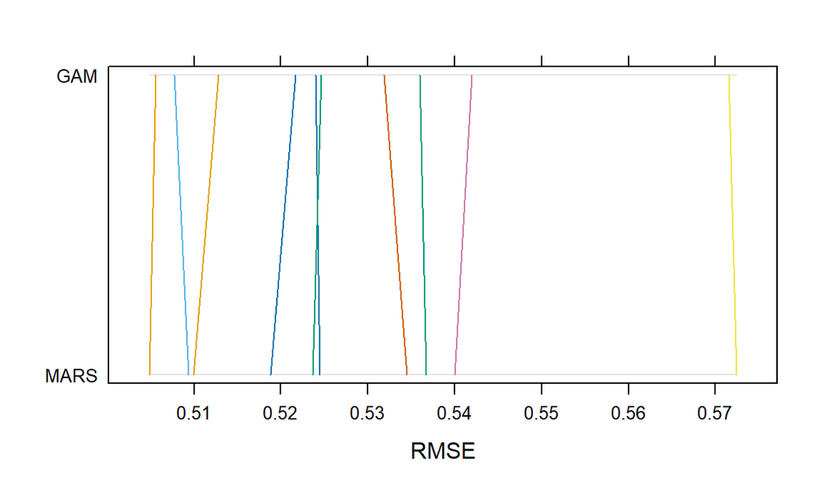

```r
parallelplot(resamp_non_linear, metric = "RMSE")
```

[figure not shown]

[output not shown]

[output not shown]

```r
bwplot(resamp_non_linear, metric = "RMSE")
```

### 4. Model Comparison between Linear and non-linear Models

```r
# MSE comparison

test_mse_table = data.frame(
  Model = c("Linear Regression", "Ridge Regression", "Lasso Regression",
            "Elastic Net Regression","Smoothing Spline", "MARS", "GAM"),
  MSE = c(lm.test.error,ridge.test.error,
          lasso.test.error, mse_ss, enet.test.error,
          mse_mars, mse_gam)
) |> arrange(MSE)

kable(test_mse_table, sort = TRUE)
```

[output not shown]

The best model is the MARS model with the smallest test error.